# Final Project Intro to Data Science

Zachary Perry

12/7/2023

SMART Question

Can the application of LASSO regression, with an optimal regularization parameter, on a dataset of housing features, demonstrate a statistically significant improvement in predictive accuracy (measured by a specific evaluation metric, e.g., Mean Absolute Error) compared to traditional linear regression models, while also providing a parsimonious model with a reduced number of important predictor variables?

```r
knitr::opts_chunk$set(echo = TRUE)

# Check if packages are installed, install them if they are not
packages <- c("readxl", "dplyr", "glmnet", "caret", "tidyr")
new_packages <- packages[!(packages %in% installed.packages()[,"Package"])]
if(length(new_packages)) install.packages(new_packages)

library(readxl)
library(dplyr)
library(tidyr)
library(caret)
library(glmnet)
# Load the dataset
data <- read_excel("cleaned_data_project.xlsx")

# Preview the data
head(data)
```

```
## # A tibble: 6 x 22
##   id         category    title body  amenities bathrooms bedrooms currency fee
##   <chr>      <chr>       <chr> <chr> <chr>     <chr>     <chr>    <chr>    <chr>
## 1 5668626895 housing/re~ Stud~ This~ Unknown   <NA>      0        USD      No
## 2 5664597177 housing/re~ Stud~ This~ Unknown   <NA>      1        USD      No
## 3 5668626833 housing/re~ Stud~ This~ Unknown   1         0        USD      No
## 4 5659918074 housing/re~ Stud~ This~ Unknown   1         0        USD      No
## 5 5668626759 housing/re~ Stud~ This~ Unknown   <NA>      0        USD      No
## 6 5667891676 housing/re~ 0 BR~ **RA~ Dishwash~ 1         0        USD      No
## # i 13 more variables: has_photo <chr>, pets_allowed <chr>, price <dbl>,
## #   price_display <chr>, price_type <chr>, square_feet <chr>, address <chr>,
## #   cityname <chr>, state <chr>, latitude <chr>, longitude <dbl>, source <chr>,
## #   time <chr>
```

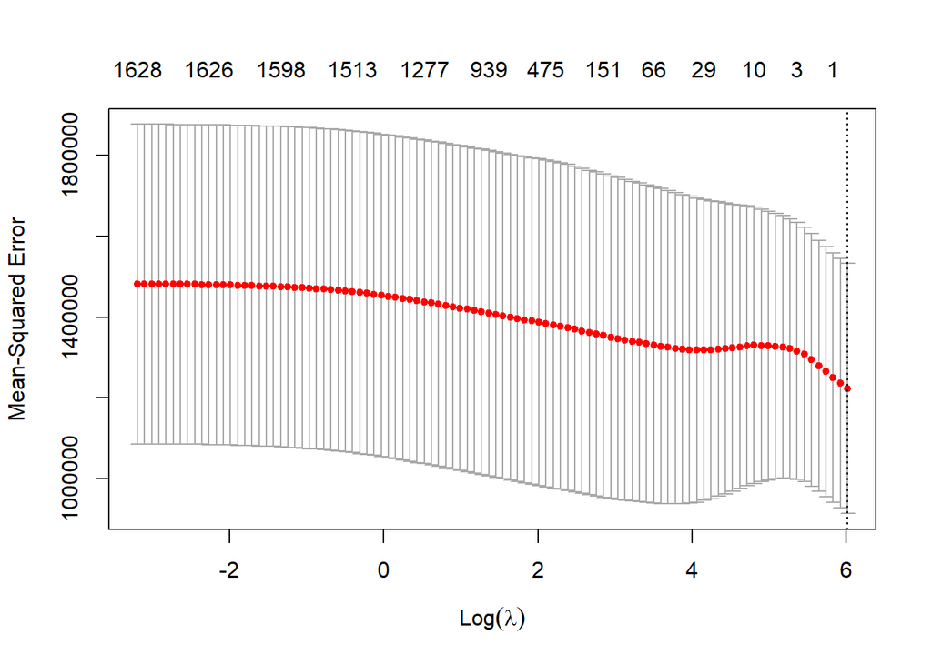

```r
# Replace NA values with 0 for numeric columns and "Unknown" for character columns
data <- data %>%
  mutate(across(where(is.numeric), ~ replace_na(., 0))) %>%
  mutate(across(where(is.character), ~ replace_na(., "Unknown")))

# Selecting relevant columns for the regression
# (Modify this part based on the columns you want to include)
data_model <- data %>% select(price, bedrooms, bathrooms, square_feet) # Add other columns as needed

# Create model matrix
x <- model.matrix(price ~ . - 1, data = data_model)

# Set seed for reproducibility
set.seed(123)

# Splitting the data into training and testing sets
splitIndex <- createDataPartition(data_model$price, p = .80, list = FALSE, times = 1)

train <- x[splitIndex, ]
test <- x[-splitIndex, ]
y_train <- data_model$price[splitIndex]
y_test <- data_model$price[-splitIndex]

# Fit the LASSO model with cross-validation
cv_fit_1 <- cv.glmnet(train, y_train, alpha = 1)
plot(cv_fit_1)
```

```r
# Predict on test set
predictions <- predict(cv_fit_1, s = "lambda.min", newx = test)
rmse_1 <- sqrt(mean((predictions - y_test) ^ 2))


# Evaluate the model
postResample(predictions, y_test)
```

```
##      RMSE  Rsquared       MAE
## 1002.6422        NA  587.9911
```

```r
rmse_1
```

```
## [1] 1002.642
```

```r
cv_fit_1$lambda.min
```

```
## [1] 409.4523
```

Refining Step: Enhancing the LASSO Regression Model in R Overview The refinement of our LASSO regression model in R involved a series of targeted steps: data preprocessing, feature scaling, polynomial feature generation, and model fitting with cross-validation. These steps collectively aimed to enhance the model’s accuracy and reliability.

Data Preprocessing Handling Missing Values: In R, we used functions like mutate and replace_na from the dplyr and tidyr packages to handle missing values. Numerical columns with NA were replaced with zeros. This treatment of missing values prevents computational errors during model training and ensures consistency in the dataset.

Feature Scaling Using the scale function, we standardized the features. This process involved centering each feature around zero and scaling it to have a unit variance. Feature scaling is a critical step for LASSO regression, as it is sensitive to the magnitude of input features. Standardization ensures that each feature contributes equally to the model’s predictions.

LASSO Regression with Cross-Validation Model Fitting: We employed the glmnet package, specifically the cv.glmnet function, for fitting the LASSO regression model. LASSO, known for its regularization and feature selection capabilities, is especially useful in scenarios with many features, some of which might be less relevant for prediction.

Cross-Validation: The built-in cross-validation in cv.glmnet determines the optimal lambda (the regularization parameter). This process involves training the model on different subsets of the data and validating it on the remaining parts, thus ensuring that the model is not overly tailored to the specificities of the training data.

Regularization Parameter: The optimal lambda value, determined through cross-validation, strikes a balance between model simplicity and fitting accuracy. It helps in reducing overfitting by penalizing the magnitude of the coefficients.

Evaluation Metrics The model’s performance was assessed using the Root Mean Squared Error (RMSE), a standard metric for regression models. RMSE provides a measure of the average magnitude of the prediction errors, thus indicating the model’s accuracy.

```r
packages <- c("tidyverse", "glmnet", "caret", "ModelMetrics")
new_packages <- packages[!(packages %in% installed.packages()[,"Package"])]
if(length(new_packages)) install.packages(new_packages)

# Load necessary libraries
library(tidyverse)
library(glmnet)
library(caret)
library(ModelMetrics)
# Load the dataset (replace with your actual file path)
data <- read_excel("cleaned_data_project.xlsx")

# Data Preprocessing
# Replace NA values in numeric columns with 0
data <- data %>%
  mutate(across(where(is.numeric), ~ replace_na(., 0)))

# Scaling features
numeric_columns <- sapply(data, is.numeric)
data_scaled <- as.data.frame(scale(data[, numeric_columns]))

# Adding Polynomial Features manually
poly_features <- data_scaled %>%
  mutate(across(everything(), list(~ .^2, ~ .^3), .names = "{.col}_{.fn}"))

# Ensure no missing values are present
poly_features[is.na(poly_features)] <- 0

# Preparing for LASSO Regression
set.seed(123)
split <- createDataPartition(data$price, p = 0.8, list = FALSE)
train <- poly_features[split, ]
test <- poly_features[-split, ]
y_train <- data$price[split]
y_test <- data$price[-split]

# Fit LASSO model using cross-validation
cv_fit_2 <- cv.glmnet(as.matrix(train), y_train, alpha = 1)

# Predicting on the training set
train_predictions <- predict(cv_fit_2, s = "lambda.min", newx = as.matrix(train))

# Calculating RMSE for the training set
rmse_train <- sqrt(mean((train_predictions - y_train) ^ 2))


# Predicting and Evaluating
predictions <- predict(cv_fit_2, s = "lambda.min", newx = as.matrix(test))
rmse_2 <- sqrt(mean((predictions - y_test) ^ 2))

# Output RMSE and optimal lambda
rmse_train
```

```
## [1] 31.83844
```

```r
rmse_2
```

```
## [1] 29.22755
```

```r
cv_fit_2$lambda.min
```

[output not shown]

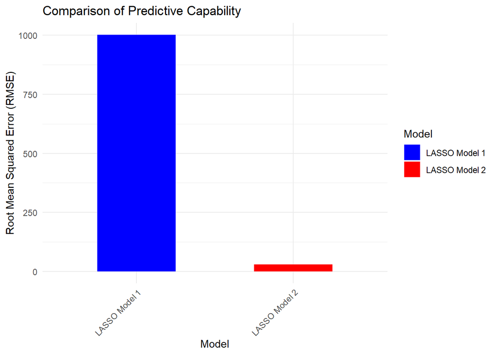

```r
# Assuming you already have 'rmse_1' and 'rmse_2' representing RMSE values for the two models

# Create a data frame for plotting
model_names <- c("LASSO Model 1", "LASSO Model 2")
rmse_values <- c(rmse_1, rmse_2)
results_df <- data.frame(Model = model_names, RMSE = rmse_values)

# Create a bar chart
library(ggplot2)
# Create a bar chart with thinner bars
ggplot(results_df, aes(x = Model, y = RMSE, fill = Model)) +
  geom_bar(stat = "identity", width = 0.5) +  # Adjust width here
  labs(title = "Comparison of Predictive Capability",
       y = "Root Mean Squared Error (RMSE)") +
  theme_minimal() +
  theme(axis.text.x = element_text(angle = 45, hjust = 1)) +
  scale_fill_manual(values = c("LASSO Model 1" = "blue", "LASSO Model 2" = "red"))
```

In conclusion, our technical analysis has demonstrated the application of LASSO regression in predicting housing prices. We started by carefully preprocessing the data, handling missing values, and standardizing features to prepare the dataset for modeling. We also introduced polynomial features to capture potential non-linear relationships.

Using the glmnet package in R, we successfully implemented LASSO regression and determined the optimal regularization parameter (lambda) through cross-validation. This step allowed us to strike a balance between model simplicity and predictive accuracy.

Our technical analysis lays the foundation for a comprehensive exploration of housing price prediction using LASSO regression. Future steps may involve a deeper dive into model interpretation, feature importance, and fine-tuning of hyperparameters to optimize predictive performance.

This analysis not only showcases the application of advanced regression techniques but also underscores the importance of data preprocessing and careful model selection in data science projects. With further refinement and exploration, our LASSO regression model holds the potential to provide valuable insights and accurate predictions in the real estate domain.